**Dynamical Systems:**  
**State Space**

Table of Contents

# 1. State of a Dynamic System

A dynamic system is said to be state-determined if a finite set of variables, called state variables, can fully characterize its behavior over time in response to any input.

## 1.1. State Variables

The state of a system at time $t_0$ is a vector of variables:

$$ \vec{x}(t_0)^T = [x_1(t_0), x_2(t_0), \dots, x_n(t_0)] $$

If the system is state-determined, then knowledge of $\vec{x}(t_0)$ and the input $\vec{u}(t)$ for $t \geq t_0$ uniquely determines the output for all $t \geq t_0$.

The number of state variables $n$ equals the number of independent energy storage elements in the system.

## 1.2. State Equations

For general nonlinear systems, the state equations are written as:

$$ \begin{aligned} \dot{x}_1 &= f_1(x, u, t) \\ \dot{x}_2 &= f_2(x, u, t) \\ &\vdots \\ \dot{x}_n &= f_n(x, u, t) \end{aligned} $$

In this course, we restrict our attention to Linear Time-Invariant (LTI) systems, for which the state equations reduce to:

$$ \dot{x}_i = \sum_{j=1}^n a_{ij} x_j + \sum_{k=1}^p b_{ik} u_k, \quad i = 1, \cdots, n \qquad \text{or} $$

$$ \dot{x_1} = a_{11}x_1 + \cdots + a_{1n}x_n \;+\; b_{11}u_1 + \cdots + b_{1p}u_p \\ \dot{x_2} = a_{21}x_1 + \cdots + a_{2n}x_n \;+\; b_{21}u_1 + \cdots + b_{2p}u_p \\ \vdots \\ \dot{x_n} = a_{n1}x_1 + \cdots + a_{nn}x_n \;+\; b_{n1}u_1 + \cdots + b_{np}u_p $$

This is a set of $n$ first-order linear differential equations.

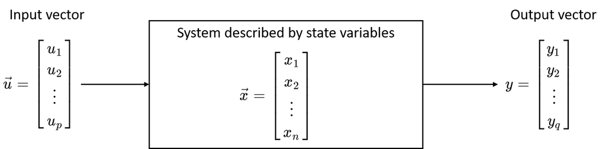

**Matrix Form**

The system equations can be written compactly as:

$$ \frac{d}{dt} \begin{bmatrix} x_1 \\ x_2 \\ \vdots \\ x_n \end{bmatrix} = A \begin{bmatrix} x_1 \\ x_2 \\ \vdots \\ x_n \end{bmatrix} + B \begin{bmatrix} u_1 \\ u_2 \\ \vdots \\ u_p \end{bmatrix} $$

or simply:

$$ \dot{x} = A x + B u $$

where:

- $x \in \mathbb{R}^n$: state vector
- $u \in \mathbb{R}^p$: input vector
- $A \in \mathbb{R}^{n \times n}$: system (state) matrix
- $B \in \mathbb{R}^{n \times p}$: input matrix

## 1.3. Output Equations

The system output $y \in \mathbb{R}^q$ is typically given as a linear combination of the states and inputs:

$$ y_i = \sum_{j=1}^n c_{ij} x_j + \sum_{k=1}^p d_{ik} u_k, \quad i = 1, \dots, q \qquad \text{or} $$

$$ y_1 = c_{11}x_1 + \cdots + c_{1n}x_n \;+\; d_{11}u_1 + \cdots + d_{1p}u_p \\ y_2 = c_{21}x_1 + \cdots + c_{2n}x_n \;+\; d_{21}u_1 + \cdots + d_{2p}u_p \\ \vdots \\ y_q = c_{q1}x_1 + \cdots + c_{qn}x_n \;+\; d_{q1}u_1 + \cdots + d_{qp}u_p \\ $$

In matrix form:

$$ \begin{bmatrix} y_1 \\ y_2 \\ \vdots \\ y_q \end{bmatrix} = \begin{bmatrix} c_{11} & c_{12} & \cdots & c_{1n} \\ & & \vdots \\ & & \vdots \\ & & & c_{qn} \end{bmatrix} \begin{bmatrix} x_1 \\ x_2 \\ \vdots \\ x_n \end{bmatrix} \;+\; \begin{bmatrix} d_{11} & d_{12} & \cdots & d_{1p} \\ & & \vdots \\ & & \vdots \\ & & & d_{qp} \end{bmatrix} \begin{bmatrix} u_1 \\ u_2 \\ \vdots \\ u_p \end{bmatrix} $$

or compactly:

$$ y = C x + D u $$

For many physical systems, the feedthrough matrix $D$ is zero: $D = 0$

## 1.4. Standard State-Space Representation

The complete state-space model of an LTI system is:

$$ \begin{aligned} \dot{x}(t) &= A x(t) + B u(t) \\ y(t) &= C x(t) + D u(t) \end{aligned} $$

This form is widely used in control systems, signal processing, and system identification.

This can be visualized as the following block diagram:

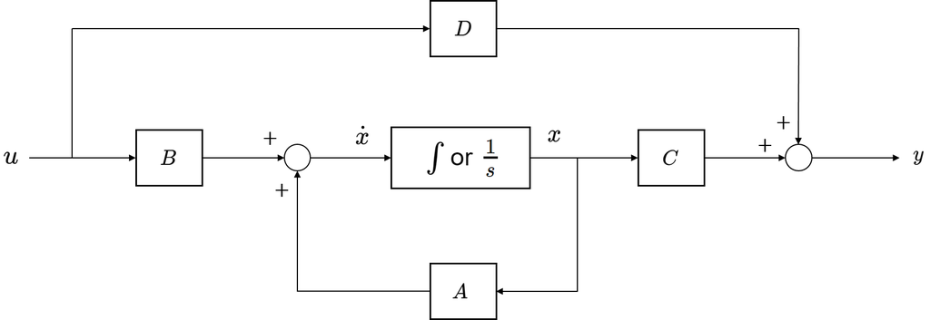

# 2. Homogeneous State Response

We begin by examining the system response in the absence of any input, i.e., for a zero-input system:

$$ u(t) = 0 $$

Then the state-space equation reduces to:

$$ \dot{x}(t) = A x(t) $$

## 2.1. Scalar Case

For intuition, consider the scalar differential equation:

$$ \dot{x}(t) = a x(t), \quad x(0) = x_0 $$

The solution is well-known:

$$ x(t) = e^{a t} x_0 $$

Verifying:

$$ \frac{d}{dt} x(t) = \frac{d}{dt} \left( e^{a t} x_0 \right) = a e^{a t} x_0 = a x(t) $$

## 2.2. Matrix Case

For vector-valued state $x(t) \in \mathbb{R}^n$, the equation

$$ \dot{x}(t) = A x(t), \quad x(0) = x_0 $$

has the general solution:

$$ x(t) = e^{A t} x_0 $$

where $e^{A t}$ is the matrix exponential, defined by the power series:

$$ e^{A t} = \sum_{k = 0}^{\infty} \frac{(A t)^k}{k!} $$

Just as in the scalar case, this function satisfies:

$$\frac{d}{dt}e^{At} = \frac{d}{dt} \sum_{k=0}^{\infty} \frac{(At)^k}{k!} = 0 + \sum_{k=1}^{\infty} \frac{kA^kt^{k-1}}{k!} = A\sum_{k=1}^{\infty} \frac{(At)^{k-1}}{(k-1)!} = A \sum_{k=0}^{\infty} \frac{(At)^k}{k!} = A e^{At}$$

so the solution indeed satisfies the differential equation:

$$ \frac{d}{dt} x(t) = A x(t) $$

## 2.3. State Transition Matrix

The matrix exponential $e^{A t}$ plays a central role in solving linear state-space models. It is called the state transition matrix, denoted:

$$ \Phi(t) = e^{A t} $$

Thus, the solution can be expressed compactly as:

$$ x(t) = \Phi(t) x(0) $$

or more generally, for any initial time $t_0$:

$$ x(t) = \Phi(t - t_0) x(t_0) $$

**Properties of the State Transition Matrix**

- Identity at $t = 0$:

$$ \Phi(0) = I $$

- Inverse property:

$$ \Phi(-t) = \Phi(t)^{-1} $$

- Time-shifting:

$$ \Phi(t_1 + t_2) = \Phi(t_1) \Phi(t_2) $$

- Consistency with initial condition:

$$ \begin{align*} x(t) &= \Phi(t) x(0) \\ &= \Phi(t) \Phi(-t_0) x(t_0) \\ &= \Phi(t - t_0) x(t_0) \end{align*} $$

This shows that state trajectories evolve linearly in time under the flow generated by $\Phi(t)$, governed solely by the system matrix $A$ in the absence of external inputs.

## 2.4. Example: Solving a Homogeneous Linear System

Given the system:

$$ \dot{x}(t) = A x(t), \qquad x(0) = x_0 $$

where

$$ A = \begin{bmatrix} -2 & 0 \\ 1 & -1 \end{bmatrix}, \qquad x_0 = \begin{bmatrix} 2 \\ 3 \end{bmatrix} $$

We wish to solve for $x(t)$ using the eigen-decomposition method:

**Step 1**: Eigenvalues and Eigenvectors

Find the eigenvalues of $A$:

$$ \det(A - \lambda I) = \begin{vmatrix} -2 - \lambda & 0 \\ 1 & -1 - \lambda \end{vmatrix} = (-2 - \lambda)(-1 - \lambda) $$

So the eigenvalues are:

$$ \lambda_1 = -2, \qquad \lambda_2 = -1 $$

Now compute the eigenvectors.

For $\lambda_1 = -2$:

$$ A - (-2)I = A + 2I = \begin{bmatrix} 0 & 0 \\ 1 & 1 \end{bmatrix} $$

Solve:

$$ \begin{bmatrix} 0 & 0 \\ 1 & 1 \end{bmatrix} \begin{bmatrix} x_1 \\ x_2 \end{bmatrix} = \begin{bmatrix} 0 \\ 0 \end{bmatrix} \quad \Rightarrow \quad x_1 = -x_2 $$

An eigenvector is:

$$ \vec{v}_1 = \begin{bmatrix} 1 \\ -1 \end{bmatrix} $$

For $\lambda_2 = -1$:

$$ A + I = \begin{bmatrix} -1 & 0 \\ 1 & 0 \end{bmatrix} $$

Solve:

$$ \begin{bmatrix} -1 & 0 \\ 1 & 0 \end{bmatrix} \begin{bmatrix} x_1 \\ x_2 \end{bmatrix} = \begin{bmatrix} 0 \\ 0 \end{bmatrix} \quad \Rightarrow \quad x_1 = 0 $$

An eigenvector is:

$$ \vec{v}_2 = \begin{bmatrix} 0 \\ 1 \end{bmatrix} $$

**Step 2**: Diagonalization of $A$

Construct the modal matrix $S$ from the eigenvectors and diagonal matrix $\Lambda$ from the eigenvalues:

$$ S = \begin{bmatrix} 1 & 0 \\ -1 & 1 \end{bmatrix}, \quad \Lambda = \begin{bmatrix} -2 & 0 \\ 0 & -1 \end{bmatrix} $$

Then

$$ e^{A t} = S e^{\Lambda t} S^{-1} $$

We compute:

$$ e^{\Lambda t} = \begin{bmatrix} e^{-2t} & 0 \\ 0 & e^{-t} \end{bmatrix} $$

Find $S^{-1}$:

$$ S^{-1} = \begin{bmatrix} 1 & 0 \\ 1 & 1 \end{bmatrix} $$

**Step 3**: Compute the Solution

Now use:

$$ x(t) = e^{At} x_0 = S e^{\Lambda t} S^{-1} x_0 $$

Substitute all known values:

$$ x(t) = \begin{bmatrix} 1 & 0 \\ -1 & 1 \end{bmatrix} \begin{bmatrix} e^{-2t} & 0 \\ 0 & e^{-t} \end{bmatrix} \begin{bmatrix} 1 & 0 \\ 1 & 1 \end{bmatrix} \begin{bmatrix} 2 \\ 3 \end{bmatrix} $$

Evaluate step by step:

(1) Multiply $S^{-1}$ by $x_0$:

$$ \begin{bmatrix} 1 & 0 \\ 1 & 1 \end{bmatrix} \begin{bmatrix} 2 \\ 3 \end{bmatrix} = \begin{bmatrix} 2 \\ 5 \end{bmatrix} $$

(2) Multiply by $e^{\Lambda t}$:

$$ \begin{bmatrix} e^{-2t} & 0 \\ 0 & e^{-t} \end{bmatrix} \begin{bmatrix} 2 \\ 5 \end{bmatrix} = \begin{bmatrix} 2e^{-2t} \\ 5e^{-t} \end{bmatrix} $$

(3) Multiply by $S$:

$$ \begin{bmatrix} 1 & 0 \\ -1 & 1 \end{bmatrix} \begin{bmatrix} 2e^{-2t} \\ 5e^{-t} \end{bmatrix} = \begin{bmatrix} 2e^{-2t} \\ -2e^{-2t} + 5e^{-t} \end{bmatrix} = \begin{bmatrix} 2e^{-2t} \\ 5e^{-t} - 2e^{-2t} \end{bmatrix} $$

Solution:

$$ x(t) = \begin{bmatrix} 2e^{-2t} \\ 5e^{-t} - 2e^{-2t} \end{bmatrix} $$

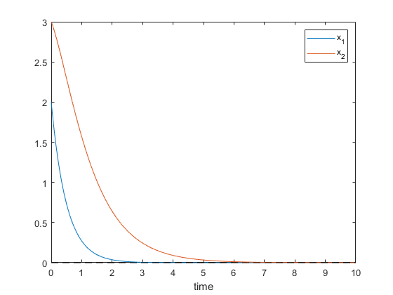

```matlab
% method 2: use 'lsim'

A = [-2, 0; 1, -1];
B = [0, 0]';
C = [1, 0;
     0, 1];
D = 0;

G = ss(A,B,C,D);

x0 = [2; 3];

t = linspace(0,10,500);
u = zeros(size(t));

[y, tout] = lsim(G,u,t,x0);

plot(tout,y,tout,zeros(size(tout)),'k--')
xlabel('time')
legend('x_1', 'x_2')
```

# 3. Forced State Response of LTI Systems

In addition to the homogeneous (zero-input) behavior, we now consider how a **linear time-invariant (LTI)** system responds to an external input.

Let the system be described by:

$$ \dot{x}(t) = A x(t) + B u(t) $$

with initial condition $x(0)$.

## 3.1. First-Order Scalar Case

Consider a scalar system:

$$ \dot{x}(t) - a x(t) = b u(t) $$

Multiply both sides by the integrating factor $e^{-at}$:

$$ e^{-at} \dot{x}(t) - a e^{-at} x(t) = e^{-at} b u(t) $$

Recognize the left-hand side as the derivative of a product:

$$ \frac{d}{dt} \left( e^{-at} x(t) \right) = b e^{-at} u(t) $$

Integrate both sides from $0$ to $t$:

$$ e^{-at} x(t) - x(0) = \int_0^t b e^{-a\tau} u(\tau) d\tau $$

Solve for $x(t)$:

$$ x(t) = e^{at} x(0) + \int_0^t e^{a(t - \tau)} b u(\tau) d\tau $$

This gives the complete solution:

- The homogeneous response $e^{at} x(0)$ depends on the initial condition
- The forced response is the convolution of the input with the system's impulse response

## 3.2. General Vector Case

For higher-order systems:

$$ \dot{x}(t) = A x(t) + B u(t), \quad x(0) = x_0 $$

The solution is:

$$ x(t) = e^{At} x(0) + \int_0^t e^{A(t - \tau)} B u(\tau) d\tau $$

This is the complete state response, where:

- $e^{At} x(0)$ is the zero-input response
- $\int_0^t e^{A(t - \tau)} B u(\tau) d\tau$ is the zero-state response

The output is given by:

$$ y(t) = C x(t) + D u(t) $$

Substitute $x(t)$:

$$ y(t) = C e^{At} x(0) + C \int_0^t e^{A(t - \tau)} B u(\tau) d\tau + D u(t) $$

Interpretation:

- $C e^{At} x(0)$: response due to initial conditions
- $C e^{At} B$: impulse response of the system
- Convolution integral: response to input $u(t)$
- $D u(t)$: feedthrough term (direct influence of input on output)

## 3.3. Alternative Notation Using State Transition Matrix

Let $\Phi(t) = e^{At}$ denote the state transition matrix.

Then the complete state response is:

$$ x(t) = \Phi(t) x(0) + \int_0^t \Phi(t - \tau) B u(\tau) d\tau $$

Verifying this solution:

At $t = 0$:

$$ x(0) = \Phi(0)x(0) + \int_0^0 \Phi(0 - \tau) B u(\tau) d\tau = x(0) $$

Differentiating using Leibniz's rule:

$$ \frac{d}{dt} \int_{0}^{t} \Phi(t - \tau) B u(\tau) d\tau = \Phi(0) B u(t) + \int_{0}^{t} \frac{\partial}{\partial t} \Phi(t - \tau) B u(\tau) d\tau $$

Since $\frac{\partial}{\partial t} \Phi(t - \tau) = A \Phi(t - \tau)$:

$$ \frac{d}{dt} x(t) = A \Phi(t) x(0) + A \int_0^t \Phi(t - \tau) B u(\tau) d\tau + B u(t) = A x(t) + B u(t) $$

Thus, the expression satisfies the original system.

## 3.4. Example: Forced Response of an LTI System

Consider the system:

$$ \begin{bmatrix} \dot{x}_1 \\ \dot{x}_2 \end{bmatrix} = \underbrace{\begin{bmatrix} -2 & 0 \\ 1 & -1 \end{bmatrix}}_{A} \begin{bmatrix} x_1 \\ x_2 \end{bmatrix} + \underbrace{\begin{bmatrix} 1 \\ 0 \end{bmatrix}}_{B} \cdot u(t), \qquad u(t) = 2 \cdot u(t), \quad x(0) = \begin{bmatrix} 0 \\ 0 \end{bmatrix} $$

**Step 1**: Use the State Transition Matrix

Since $x(0) = 0$, the state response is:

$$ x(t) = \int_0^t \Phi(t - \tau) B u(\tau) \, d\tau $$

Given $u(\tau) = 2$ for $\tau \geq 0$, we get:

$$ x(t) = 2 \int_0^t \Phi(t - \tau) B \, d\tau $$

**Step 2**: Given $\Phi(t)$

The state transition matrix is:

$$ \Phi(t) = e^{At} = \begin{bmatrix} e^{-2t} & 0 \\ e^{-t} - e^{-2t} & e^{-t} \end{bmatrix} $$

Then:

$$ x(t) = \Phi(t) \int_0^t \Phi(-\tau) B \cdot 2 \, d\tau $$

**Step 3**: Evaluate the Integral

Compute:

$$ \Phi(-\tau)B = \begin{bmatrix} e^{2\tau} \\ e^{\tau} - e^{2\tau} \end{bmatrix} $$

Then:

$$ \int_0^t 2 \begin{bmatrix} e^{2\tau} \\ e^{\tau} - e^{2\tau} \end{bmatrix} d\tau = \begin{bmatrix} e^{2t} - 1 \\ 2e^t - e^{2t} - 1 \end{bmatrix} $$

**Step 4**: Multiply by $\Phi(t)$

Now:

$$ x(t) = \Phi(t) \begin{bmatrix} e^{2t} - 1 \\ 2e^t - e^{2t} - 1 \end{bmatrix} $$

Compute:

$$ x_1(t) = e^{-2t}(e^{2t} - 1) = 1 - e^{-2t} $$

## Appendix: Leibniz Integral Rule

Let $\mathbf{F}(t)$ be defined as an integral with time-varying limits:

$$ \mathbf{F}(t) = \int_{a(t)}^{b(t)} f(t, \tau) \, d \tau $$

Then the total derivative of $\mathbf{F}(t)$ is given by:

$$ \frac{d \mathbf{F}(t)}{d t} = \int_{a(t)}^{b(t)} \frac{\partial f(t, \tau)}{\partial t} \, d \tau + f(t, b(t)) \frac{d b(t)}{d t} - f(t, a(t)) \frac{d a(t)}{d t} $$

**Proof Sketch**

We proceed in stages to build intuition.

**Case 1: Univariate Function with Time in Upper or Lower Limit**

Let $f(\tau)$ be a scalar function of one variable.

**(a)** If:

$$ F(t) = \int_{t_0}^{t} f(\tau) \, d\tau $$

Then by the Fundamental Theorem of Calculus:

$$ \frac{dF(t)}{dt} = f(t) $$

**(b)** If:

$$ F(t) = \int_{t}^{t_0} f(\tau) \, d\tau $$

Then:

$$ \frac{dF(t)}{dt} = -f(t) $$

**Case 2: Two-Variable Function with Fixed Limits**

Let $f(t, \tau)$ be a function of two variables and define:

$$ F(t) = \int_{a}^{b} f(t, \tau) \, d\tau \quad \text{(where $a, b$ are constant)} $$

Then the derivative is:

$$ \frac{dF(t)}{dt} = \int_{a}^{b} \frac{\partial f(t, \tau)}{\partial t} \, d\tau $$

**Case 3: Two-Variable Function with Time-Dependent Limits**

Let $a(t)$ and $b(t)$ be differentiable functions of $t$, and define:

$$ \mathbf{F}(t) = \int_{a(t)}^{b(t)} f(t, \tau) \, d \tau $$

Then by the general form of Leibniz’s Rule:

$$ \frac{d \mathbf{F}(t)}{d t} = \int_{a(t)}^{b(t)} \frac{\partial f(t, \tau)}{\partial t} \, d \tau + f(t, b(t)) \frac{d b(t)}{d t} - f(t, a(t)) \frac{d a(t)}{d t} $$

**Special Case**

If $a(t) = t_0$ (constant), $b(t) = t$:

$$ \mathbf{F}(t) = \int_{t_0}^{t} f(t, \tau) \, d\tau $$

Then:

$$ \frac{d \mathbf{F}(t)}{dt} = \int_{t_0}^{t} \frac{\partial f(t, \tau)}{\partial t} \, d\tau + f(t, t) $$

This version is especially useful when evaluating solutions to time-domain convolution integrals in LTI systems.

Note: Leibniz Integral Rule

If $\mathbf{F}(t) = \int_{a(t)}^{b(t)} f(t, \tau) d \tau$, then

$$\frac{d \mathbf{F}}{d t} = \int_{a(t)}^{b(t)} \frac{\partial f(t, \tau)}{\partial t} d \tau + f(t, b(t)) \frac{d b}{d t} - f(t, a(t)) \frac{d a}{d t}$$

Proof.

Suppose $f$ is a univariate function

$$ \begin{align*} F(t) = \int_{t_0}^{t} f(\tau) d \tau &\quad \implies \quad \frac{d F (t)}{d t} = f(t) \\\\ F(t) = \int_{t}^{t_0} f(\tau) d \tau &\quad \implies \quad \frac{d F (t)}{d t} = -f(t) \end{align*} $$

Now suppose $f$ is a function of two variables ($a$ and $b$ are constant)

$$ \begin{align*} F(t) = \int_{a}^{b} f(t, \tau) d \tau \quad \implies \quad \frac{d F(t)}{d t} = \int_{a}^{b} \frac{\partial f(t, \tau)}{\partial t} d \tau \end{align*} $$

Now suppose the limits of integration $a$ and $b$ themselves depend on $t$,

$$\mathbf{F}(t) = F(t, a(t), b(t)) = \int_{a(t)}^{b(t)} f(t, \tau) d \tau$$

$$ \begin{align*} \frac{d \mathbf{F}(t)}{d t} &= \frac{\partial F}{\partial t} + \frac{\partial F}{\partial a} \frac{d a}{d t} + \frac{\partial F}{\partial b}\frac{d b}{d t} \\\\ &= \int_{a(t)}^{b(t)} \frac{\partial f(t, \tau)}{\partial t} d \tau + f(t, b(t))\frac{d b}{d t} - f(t,a(t))\frac{d a}{d t}\\\\ \frac{d}{dt} \int_{t_0}^{t} f(t,\tau) d \tau &= \int_{t_0}^{t} \frac{\partial f(t,\tau)}{\partial t} d \tau + f(t,t) \end{align*} $$

## 3.5. Response of LTI Systems to Singularity Inputs

The general state-space solution to an LTI system is:

$$ x(t) = e^{At}x(0) + \int_0^t e^{A(t - \tau)} Bu(\tau)\, d\tau $$

This expression shows the total response as a combination of the homogeneous solution and the forced response due to input $u(t)$.

### 3.5.1. Impulse Input

Suppose the input is an impulse:

$$ u(t) = K\delta(t), \quad K = \begin{bmatrix} k_1 \\ k_2 \\ \vdots \\ k_p \end{bmatrix} $$

Then the state becomes:

$$ \begin{align*} x(t) &= e^{At}x(0) + \int_0^t e^{A(t - \tau)} B K \delta(\tau) \, d\tau \\ &= e^{At}x(0) + e^{At} B K \\ &= e^{At} \left(x(0) + BK\right) \end{align*} $$

**Interpretation**: The effect of an impulse at $t = 0$ is equivalent to a jump in the initial state:

$$ x(0^+) = x(0^-) + BK $$

This is particularly useful in modeling discontinuities in physical systems such as impulsive forces.

$$ u(t) = Ku_{\text{step}} = \begin{bmatrix} k_1 \\ k_2 \\ \vdots \\ k_p \end{bmatrix} u_{\text{step}}(t) $$

### 3.5.2. Step Input

Now consider a step input:

$$ u(t) = K \cdot u_{\text{step}}(t) = \begin{bmatrix} k_1 \\ k_2 \\ \vdots \\ k_p \end{bmatrix} u_{\text{step}}(t) $$

Then the response is:

$$ \begin{align*} x(t) &= e^{At}x(0) + \int^t_0 e^{A(t-\tau)}Bu(\tau)d\tau \\ &= e^{At}x(0) + \int^t_0 e^{A(t-\tau)}BKd\tau \\ &= e^{At}x(0) + e^{At}\int^t_0 e^{-A\tau}d\tau BK \\ &= e^{At}x(0) + e^{At}[-A^{-1}e^{-A\tau} \big\rvert^t_0] BK \\ &= e^{At}x(0) + e^{At}[-A^{-1}e^{-At} + A^{-1}] BK \\ &= e^{At}x(0) + e^{At}A^{-1}[I - e^{-At}] BK \\ &= e^{At}x(0) + A^{-1}[e^{At} - I] BK \qquad (Ae^{At} = e^{At}A) \end{align*} $$

**Steady-State Behavior**

If the system is stable (i.e., all eigenvalues of $A$ have negative real parts), then:

$$ \lim_{t \to \infty} e^{At} = 0 \quad \Rightarrow \quad \lim_{t \to \infty} x(t) = -A^{-1} BK $$

This gives the final state in response to a constant step input.

**Example: Step Response of a Mass-Spring-Damper System**

Consider the second-order differential equation of a damped mass-spring system under a step input force:

$$ \ddot{y} + \frac{c}{m} \dot{y} + \frac{k}{m} y = g \cdot u_{\text{step}}(t) $$

**Step 1**: State-Space Representation

Let us define state variables:

$$ x_1 = y, \quad x_2 = \dot{y} $$

Then the system can be written in state-space form:

$$ \dot{x} = \begin{bmatrix} \dot{x}_1 \\ \dot{x}_2 \end{bmatrix} = \underbrace{\begin{bmatrix} 0 & 1 \\ -\frac{k}{m} & -\frac{c}{m} \end{bmatrix}}_{A} \begin{bmatrix} x_1 \\ x_2 \end{bmatrix} + \underbrace{\begin{bmatrix} 0 \\ g \end{bmatrix}}_{B} u(t) $$

with output equation:

$$ y(t) = \begin{bmatrix} 1 & 0 \end{bmatrix} \begin{bmatrix} x_1 \\ x_2 \end{bmatrix} = x_1(t) $$

**Step 2**: Steady-State Response to Step Input

For a unit step input, $u(t) = 1 \cdot u_{\text{step}}(t)$, we use the steady-state result for LTI systems:

$$ x(\infty) = -A^{-1} B \cdot 1 $$

Compute the inverse of the matrix $A$:

$$ A = \begin{bmatrix} 0 & 1 \\ -\frac{k}{m} & -\frac{c}{m} \end{bmatrix}, \quad \det(A) = 0 \cdot \left(-\frac{c}{m}\right) - 1 \cdot \left(-\frac{k}{m}\right) = \frac{k}{m} $$

Using the $2 \times 2$ inverse formula:

$$ A^{-1} = \frac{1}{\frac{k}{m}} \begin{bmatrix} -\frac{c}{m} & -1 \\ \frac{k}{m} & 0 \end{bmatrix} = \frac{m}{k} \begin{bmatrix} -\frac{c}{m} & -1 \\ \frac{k}{m} & 0 \end{bmatrix} = \begin{bmatrix} -\frac{c}{k} & -\frac{m}{k} \\ 1 & 0 \end{bmatrix} $$

Then:

$$ x(\infty) = -A^{-1} B K = - \begin{bmatrix} -\frac{c}{k} & -\frac{m}{k} \\ 1 & 0 \end{bmatrix} \begin{bmatrix} 0 \\ g \end{bmatrix} \cdot 1 = - \begin{bmatrix} -\frac{m}{k} g \\ 0 \end{bmatrix} = \begin{bmatrix} \frac{m g}{k} \\ 0 \end{bmatrix} $$

**Interpretation**

- The steady-state displacement of the mass is:

$$ y(\infty) = x_1(\infty) = \frac{mg}{k} $$

- The velocity goes to zero as $t \to \infty$, i.e., $x_2(\infty) = 0$

This result is physically intuitive: the final displacement under a constant force $mg$ balances the spring force:

$$ k y = mg \quad \Rightarrow \quad y = \frac{mg}{k} $$

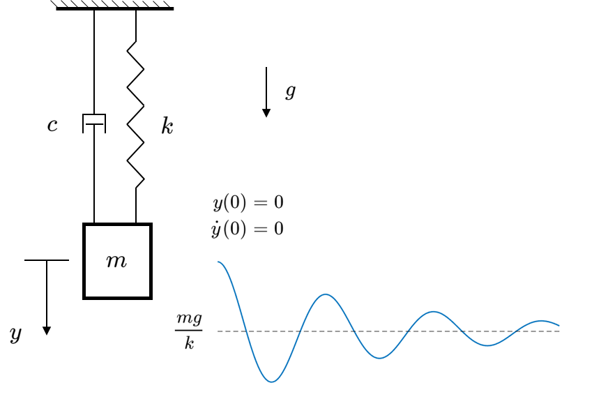

```matlab
%%javascript
$.getScript('https://kmahelona.github.io/ipython_notebook_goodies/ipython_notebook_toc.js')
```